# Netflix Recommendation System

# MISSING VALUES

```python
data.isnull().sum()
```

```
show_id            0
type               0
title              0
director        2634
cast             825
country          831
date_added        10
release_year       0
rating             4
duration           3
listed_in          0
description        0
dtype: int64
```

```python
data.describe()
```

|  | release_year |
| --- | --- |
| count | 8807.000000 |
| mean | 2014.180198 |
| std | 8.819312 |
| min | 1925.000000 |
| 25% | 2013.000000 |
| 50% | 2017.000000 |
| 75% | 2019.000000 |
| max | 2021.000000 |

```python
data.isnull().sum()
```

```
show_id            0
type               0
title              0
director        2634
cast             825
country          831
date_added        10
release_year       0
rating             4
duration           3
listed_in          0
description        0
dtype: int64
```

```python
total =data.isnull().sum().sort_values(ascending=False)
total
```

```
director        2634
country          831
cast             825
date_added        10
rating             4
duration           3
description        0
listed_in          0
release_year       0
title              0
type               0
show_id            0
dtype: int64
```

```python
percent=(data.isnull().mean()*100).sort_values(ascending=False)
percent
```

```
director        29.908028
country          9.435676
cast             9.367549
date_added       0.113546
rating           0.045418
duration         0.034064
description      0.000000
listed_in        0.000000
release_year     0.000000
title            0.000000
type             0.000000
show_id          0.000000
dtype: float64
```

```python
missing_data = pd.concat([total, percent], axis=1, keys=['Total', 'Percent'])
```

```python
missing_data
```

|  | Total | Percent |
| --- | --- | --- |
| director | 2634 | 29.908028 |
| country | 831 | 9.435676 |
| cast | 825 | 9.367549 |
| date_added | 10 | 0.113546 |
| rating | 4 | 0.045418 |
| duration | 3 | 0.034064 |
| description | 0 | 0.000000 |
| listed_in | 0 | 0.000000 |
| release_year | 0 | 0.000000 |
| title | 0 | 0.000000 |
| type | 0 | 0.000000 |
| show_id | 0 | 0.000000 |

```python
missing_data=missing_data.drop((missing_data[missing_data['Total']==0]).index,0)
```

```python
missing_data
```

|  | Total | Percent |
| --- | --- | --- |
| director | 2634 | 29.908028 |
| country | 831 | 9.435676 |
| cast | 825 | 9.367549 |
| date_added | 10 | 0.113546 |
| rating | 4 | 0.045418 |
| duration | 3 | 0.034064 |

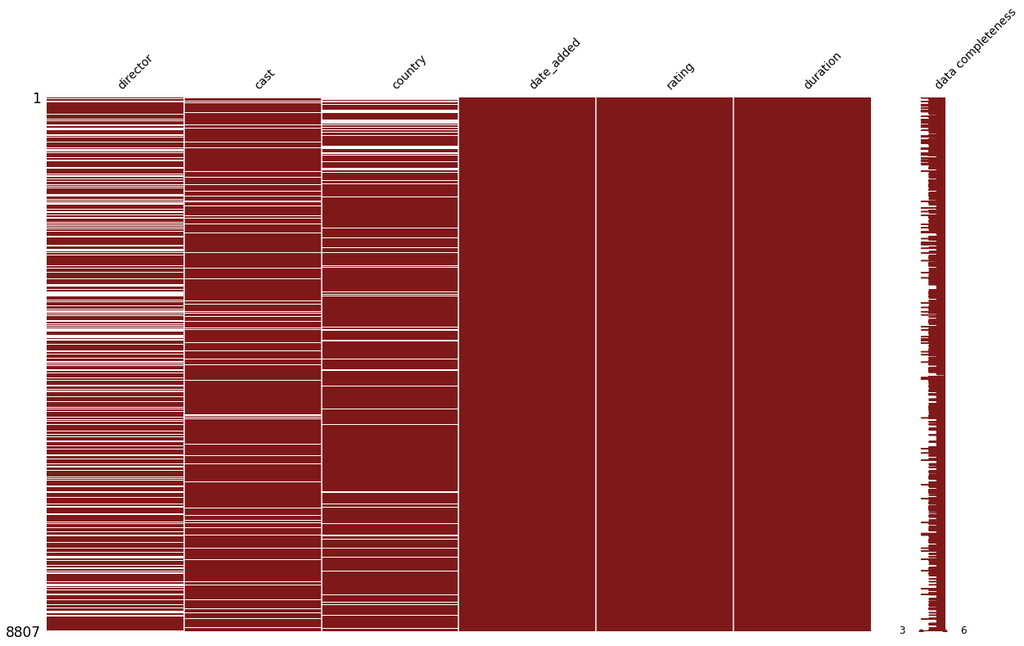

```python
null_cols =(data.isna().sum()[data.isna().sum()>0]).index
msno.matrix(data.loc[:,null_cols],labels=True,figsize=(20,12),fontsize=14,inline=False ,color=(0.5,0.1,0.1))
plt.show()
```

## That's a big number, 30% of directors are missing and 9% of cast and country 9%

# Check for duplicate rows

```python
print(f"There are {data.duplicated().sum()} duplicate rows in the data set.")
```

```
There are 0 duplicate rows in the data set.
```

## There are no duplicates in the dataset

# Removing the missing values from dataset

```python
data.dropna(subset=['director','cast','country','date_added','rating','duration'],axis=0,inplace=True)
print("Details after dropping null rows and columns")
print("Total Rows: {}\nTotal Columns: {}".format(data.shape[0],data.shape[1]))
```

```
Details after dropping null rows and columns
Total Rows: 5332
Total Columns: 12
```

```python
data.isnull().sum()
```

```
show_id         0
type            0
title           0
director        0
cast            0
country         0
date_added      0
release_year    0
rating          0
duration        0
listed_in       0
description     0
dtype: int64
```

## Now there are no missing values in the dataset

```
Text(0,0.5,'Count Of Content')
```

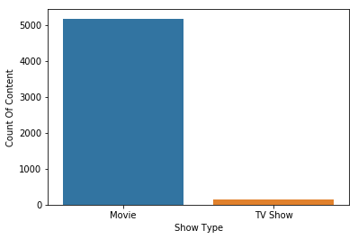

```python
sns.countplot(x = 'type', data = data)
plt.xlabel("Show Type")
plt.ylabel("Count Of Content")
```

# A majority of the added content on netflix seem to be movies

```python
def barplot(column,df):
    bar_plot1 = sns.countplot(x=column, data=df)

    total = len(df[column])
    for p in bar_plot1.patches:
        percentage = '{:.2f}%'.format(100 * p.get_height()/total)
        height = p.get_height()
        bar_plot1.text(p.get_x()+ p.get_width()/2, height + 30, percentage, ha="center")
```

```
Text(0.5,1,'TV Show ratings frequency')
```

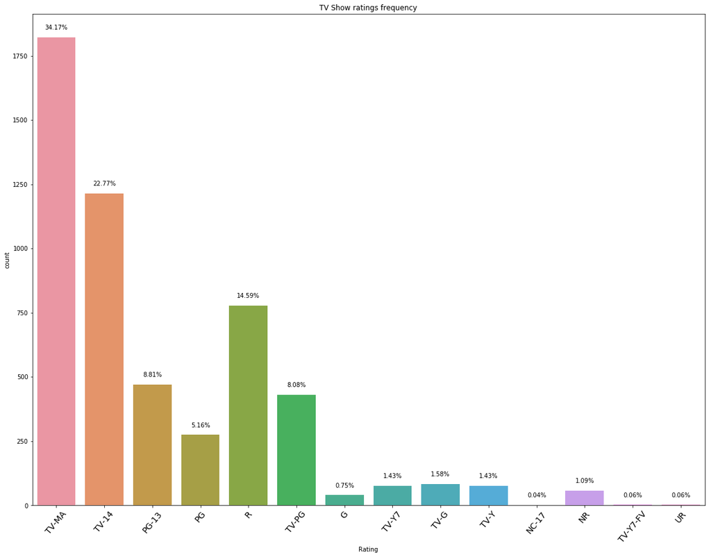

```python
plt.figure(figsize=(20, 15))
plt.xticks(fontsize=14, rotation=50)
barplot("rating",data)
plt.xlabel("Rating")
plt.title("TV Show ratings frequency")
```

- TV-MA: Mature Audience
- PG-13: Parents strongly cautioned. May be Inappropriate for ages 12 and under
- TV-PG: Parental Guidance suggested
- TV-14: Parents strongly cautioned. May not be suitable for ages 14 and under
- TV-G: Suitable for GeneralM Audiences
- TV-Y: Designed to be appropriate for all children

### Netflix targets older/mature audience as there are several contents rated as "TV Mature Audience (TV-MA)"

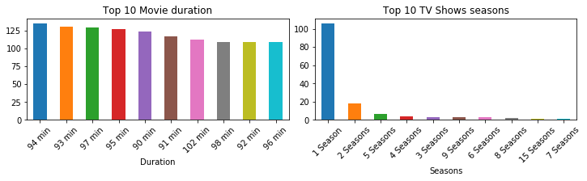

```python
plt.figure(figsize=(10,3))

plt.subplot(1,2,1)
movies_duration = data[data['type'] == "Movie"]
movies_duration = movies_duration['duration'].value_counts()[:10]
movies_duration.plot(kind='bar',title='Number of movies over the years')
plt.xlabel("Duration")
plt.title("Top 10 Movie duration")
plt.xticks(rotation = 45)

plt.subplot(1,2,2)
show_duration = data[data['type'] == "TV Show"]
show_duration = show_duration['duration'].value_counts()[:10]
show_duration.plot(kind='bar',title='Number of TV shows over the years')
plt.xlabel("Seasons")
plt.title("Top 10 TV Shows seasons")
plt.xticks(rotation = 45)

plt.tight_layout(pad=0.3)
```

## The length of each movie is mostly above 1 and a half hour, whereas several TV Shows seems to be limited series of 1 season.

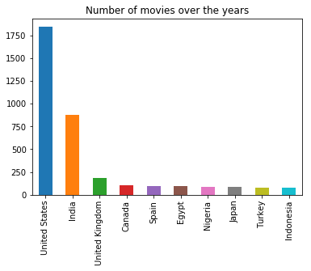

```python
country = data['country'].value_counts()[:10]
country.plot(kind='bar',title='Number of movies over the years')
```

## The United States of America is the leading content contributor followed by India.

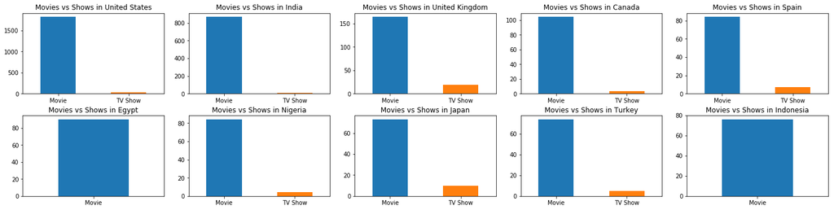

```python
plt.figure(figsize=(20,5))

for i in range(len(country.index)):
    plt.subplot(2,5,i+1)
    moviesvsshows = data[data['country'] == country.index[i]]
    moviesvsshows = moviesvsshows['type'].value_counts()
    moviesvsshows.plot(kind='bar')
    plt.title("Movies vs Shows in {}".format(country.index[i]))
    plt.xticks(rotation = 360)

plt.tight_layout(pad=0.5)
```

## It seems that in most countries more movies are produced than series

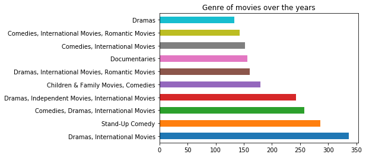

```python
genre = data["listed_in"].value_counts()[:10]
genre.plot(kind='barh',title='Genre of movies over the years')
```

## Netflix offer a number of Stand-ups, Dramas and International Movies

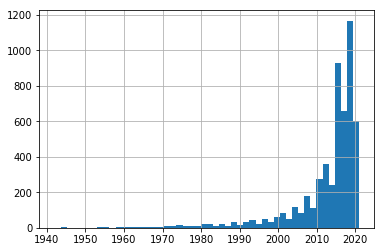

```python
data["release_year"].hist(bins=50)
```

## Most movies tend to have been released not so long ago

## Let us now look at the directors

```python
data["director"].value_counts()
```

```
Raúl Campos, Jan Suter               18
Marcus Raboy                         15
Jay Karas                            14
Cathy Garcia-Molina                  13
Martin Scorsese                      12
Jay Chapman                          12
Youssef Chahine                      12
Steven Spielberg                     11
Don Michael Paul                     10
David Dhawan                          9
Johnnie To                            8
Robert Rodriguez                      8
Ryan Polito                           8
Troy Miller                           8
Yılmaz Erdoğan                        8
Hakan Algül                           8
Shannon Hartman                       8
Clint Eastwood                        7
Justin G. Dyck                        7
McG                                   7
Quentin Tarantino                     7
Toshiya Shinohara                     7
Kunle Afolayan                        7
Ron Howard                            7
Lance Bangs                           7
Ram Gopal Varma                       7
Rajkumar Santoshi                     6
Ozan Açıktan                          6
Mae Czarina Cruz                      6
Steven Soderbergh                     6
                                     ..
Just Philippot                        1
Kelly Reichardt                       1
Wim Wenders                           1
Joe Nussbaum                          1
Phil Nibbelink, Simon Wells           1
Shady Hanna                           1
Robbie Countryman                     1
Chanon Yingyong, Phuwanit Pholdee     1
Joel Hopkins                          1
Osman Ali                             1
David Wnendt                          1
Cal Brunker                           1
Hayao Miyazaki                        1
Gordon Parks                          1
Richard Attenborough                  1
Greg Berlanti                         1
John Murlowski                        1
Zack Whedon                           1
Nic Mathieu                           1
Amol Palekar                          1
Shojiro Nishimi, Guillaume Renard     1
Simon Napier-Bell                     1
Simranjit Singh Hundal                1
Chris Jenkins                         1
Nguyen Thanh Tung                     1
Atul Malhotra                         1
Natalie Portman                       1
Brian O'Malley                        1
Cheng Wei-hao                         1
Jitender Pawar                        1
Name: director, Length: 3945, dtype: int64
```

### We see that in some cases there is more than one director. Let us get the number of directors in each movie

```python
data["director_number"] = data["director"].str.split(',').str.len()
data["director_number"].describe()
```

```
count    5332.000000
mean        1.117779
std         0.549558
min         1.000000
25%         1.000000
50%         1.000000
75%         1.000000
max        13.000000
Name: director_number, dtype: float64
```

## Seems that there were movies/series with many directors. Let us take a closer look:

```python
data[["title"]][data["director_number"] > 5].size
```

```
11
```

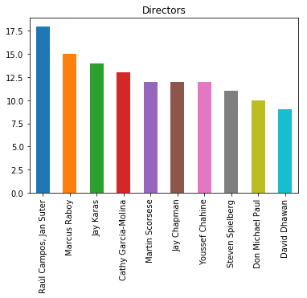

```python
country = data['director'].value_counts()[:10]
country.plot(kind='bar',title='Directors')
```

## Let us look at date the movie or series was added:

```python
data["date_added"].head()
```

```
7     September 24, 2021
8     September 24, 2021
9     September 24, 2021
12    September 23, 2021
24    September 21, 2021
Name: date_added, dtype: object
```

## It would make sense to convert the type to date:

```python
data["date_added"] = pd.to_datetime(data["date_added"])
```

## We now plot:

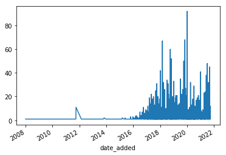

```python
data.groupby("date_added").size().plot(kind="line")
```

## Most were added after 2016. Let us zoom in on that part of the graph:

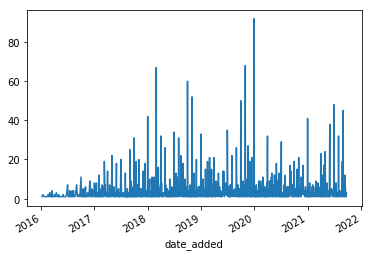

```python
data[data["date_added"] > pd.Timestamp(2016, 1, 1)].groupby("date_added").size().plot(kind="line")
```

## We see that there is a peak around the year 2020.

An interesting thing to check is whether the movies and series are released soon after they are produced or whether they are "old". To check this, we subtract the year of date added and the year of date released. First assume that movies were released in the middle of the year since the information is not provided:

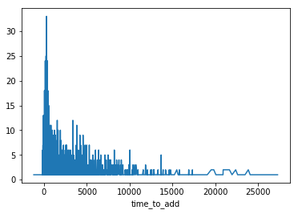

```python
release_year = data["release_year"].apply(lambda x: pd.Timestamp(x, 7, 1))
# now get the difference between date added and date released for each movie
data["time_to_add"] = (data["date_added"] - release_year).dt.days
data.groupby("time_to_add").size().plot(kind="line")
```

## The vast majority are less than 5000 days old. Let us zoom in on that area:

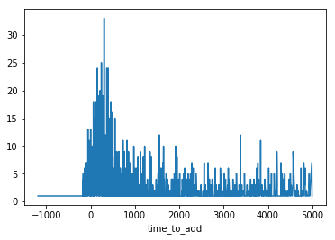

```python
data[data["time_to_add"] < 5000].groupby("time_to_add").size().plot(kind="line")
```

## Many movies and series are less than one year old when they are released.

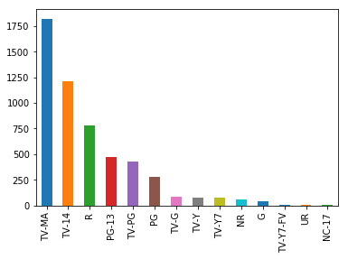

```python
data["rating"].value_counts().plot(kind="bar")
```

# WordCloud for Genres.

```python
from collections import Counter

genres=list(data['listed_in'])
gen=[]

for i in genres:
    i=list(i.split(','))
    for j in i:
        gen.append(j.replace(' ',""))
g=Counter(gen)
```

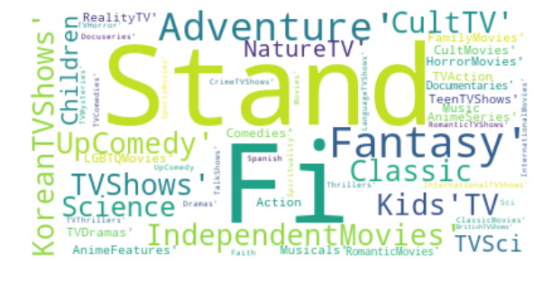

```python
from wordcloud import WordCloud, STOPWORDS, ImageColorGenerator
from PIL import Image

text = list(set(gen))
plt.rcParams['figure.figsize'] = (10,10)

#assigning shape to the word cloud

wordcloud = WordCloud(max_words=1000000,background_color="white").generate(str(text))

plt.imshow(wordcloud,interpolation="bilinear")
plt.axis("off")
plt.show()
```

# Words that are mostly used in the description of content

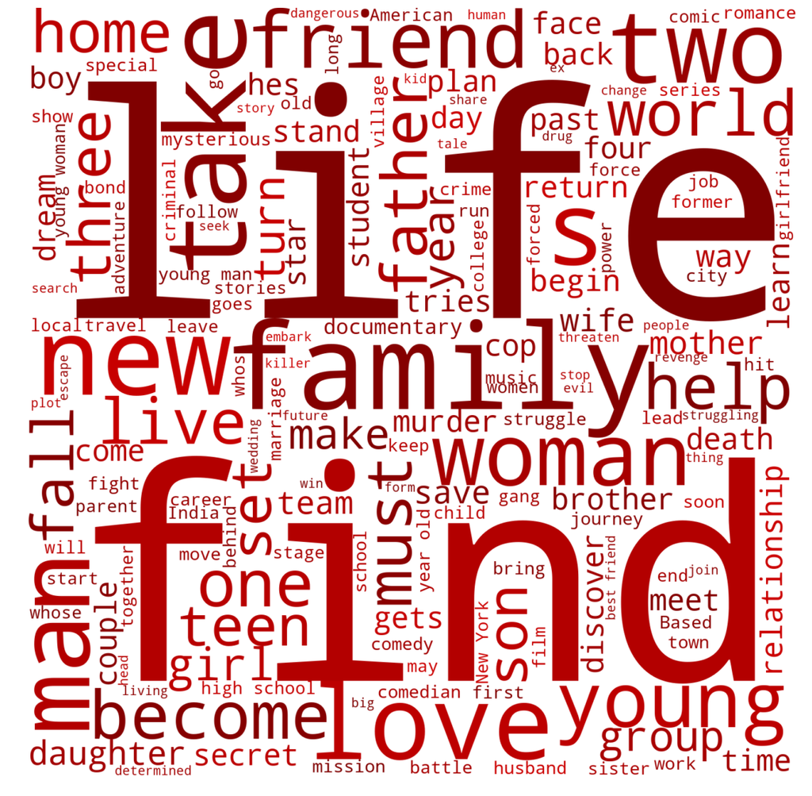

```python
from wordcloud import WordCloud
from PIL import Image
import random
import matplotlib.pyplot as plt
import requests

text = str(list(data['description'])).replace(',', '').replace('[', '').replace("'", '').replace(']', '').replace('.', '')

def red_color_func(word, font_size, position, orientation, random_state = None, **kwargs):
    return "hsl(0, 100%%, %f%%)" % random.randint(25, 40)

plt.rcParams['figure.figsize'] = (20, 20)
wordcloud = WordCloud(background_color = 'white', width = 1400,  height = 1400, max_words = 170).generate(text)

wordcloud.recolor(color_func = red_color_func)

plt.imshow(wordcloud, interpolation = 'bilinear')
plt.axis('off')
plt.show()
```